# R Basics

## The Tidyverse

The tidyverse is a weird name for a collection of user-written packages and functions that really are core to why people use R. These packages are nice in that they share a common format for commands. Click the “play” button in the top right of the gray box below to install the tidyverse on your own computer, if it’s not already.

```r
# This syntax is common for R --
# Parameters for a command are included in parentheses.
install.packages('tidyverse')

# Note that the hash tag indicates a comment.
```

## Loading Data

There are a few different ways to load data into R. The code below gives some examples. First though, you’ll need to set the working directory. If you’re doing this in an R project file this is automatic. If not, use the following command:

```r
setwd("C:/Users/andre/Box/LearningR") # Change the path to your location
```

Now that R knows where all our files are we can get started. By itself, base R is pretty dumb. It doesn’t know how to read many file types (outside of a `.csv`). We need to load some of the packages we installed from the tidyverse before we can access `.dta` files or `.xlsx` files.

### Loading STATA files

There are two ways to load those packages. The first is to type the name of the package before each command. For example, to read a `.dta` file using the haven package, you’d type:

`haven::read_dta('path to the file')`.

It’s kinda a pain to have to type the package name before every command though. Instead we’ll load the package into the work space.

```r
library('haven') # Loads the haven packages to read/write .dta files.

# Here I load a file hosted on github, but you could also just have a file path.

scholarship <- read_dta("https://raw.github.com/andrewmcamp/LearningR/main/scholarship.dta")
```

Let’s take a quick look at our data. There are a few options:

```r
names(scholarship) # Names just lists the variable names.
```

```
[1] "id"        "female"    "ethnicity" "frpl"      "math08"    "ela08"     "promise"   "sat"
```

```r
head(scholarship) # Head displays the first 6 rows.
```

| id | female | ethnicity | frpl | math08 | ela08 | promise | sat |
| --- | --- | --- | --- | --- | --- | --- | --- |
| 1 | 1 | 1.black | 0 | 427.4159 | 414.0510 | 0 | 716.0543 |
| 2 | 1 | 1.black | 1 | 719.4366 | 679.7741 | 0 | 1144.2920 |
| 3 | 0 | 3.white | 1 | 476.5799 | 591.5301 | 0 | 863.3759 |
| 4 | 0 | 2.hispanic | 1 | 606.9895 | 521.8466 | 0 | 965.6304 |
| 5 | 0 | 2.hispanic | 1 | 591.6918 | 554.1521 | 0 | 971.6695 |
| 6 | 1 | 2.hispanic | 0 | 649.5814 | 546.9682 | 1 | 1182.2269 |

That’s nice, but how do we get rid of that data set now?

```r
ls()
```

```
[1] "scholarship"
```

```r
rm(list=ls())
```

### Loading Package Data

Packages also have data. This can be super handy. Some packages, like `tidycensus` allow you to easily pull census data into your project. Other ones, [like the Urban Institute’s education data package](https://github.com/UrbanInstitute/education-data-package-r), let you query and pull in data from IPEDS, NCES Common Core of Data, and others.

I’ll be using some California school data from the `AER` package for the rest of the examples.

```r
# Install the AER package if you haven't already.
#install.package('AER')

library(AER)
# We can now access the data included with the AER package.
data('CASchools')
```

## Simple Descriptive Statistics

Let’s take a closer look at this data

```r
summary(CASchools)
```

```
   district            school                  county      grades       students
 Length:420         Length:420         Sonoma     : 29   KK-06: 61   Min.   :   81.0
 Class :character   Class :character   Kern       : 27   KK-08:359   1st Qu.:  379.0
 Mode  :character   Mode  :character   Los Angeles: 27               Median :  950.5
                                       Tulare     : 24               Mean   : 2628.8
                                       San Diego  : 21               3rd Qu.: 3008.0
                                       Santa Clara: 20               Max.   :27176.0
                                       (Other)    :272
    teachers          calworks          lunch           computer       expenditure       income
 Min.   :   4.85   Min.   : 0.000   Min.   :  0.00   Min.   :   0.0   Min.   :3926   Min.   : 5.335
 1st Qu.:  19.66   1st Qu.: 4.395   1st Qu.: 23.28   1st Qu.:  46.0   1st Qu.:4906   1st Qu.:10.639
 Median :  48.56   Median :10.520   Median : 41.75   Median : 117.5   Median :5215   Median :13.728
 Mean   : 129.07   Mean   :13.246   Mean   : 44.71   Mean   : 303.4   Mean   :5312   Mean   :15.317
 3rd Qu.: 146.35   3rd Qu.:18.981   3rd Qu.: 66.86   3rd Qu.: 375.2   3rd Qu.:5601   3rd Qu.:17.629
 Max.   :1429.00   Max.   :78.994   Max.   :100.00   Max.   :3324.0   Max.   :7712   Max.   :55.328

    english            read            math
 Min.   : 0.000   Min.   :604.5   Min.   :605.4
 1st Qu.: 1.941   1st Qu.:640.4   1st Qu.:639.4
 Median : 8.778   Median :655.8   Median :652.5
 Mean   :15.768   Mean   :655.0   Mean   :653.3
 3rd Qu.:22.970   3rd Qu.:668.7   3rd Qu.:665.9
 Max.   :85.540   Max.   :704.0   Max.   :709.5
```

```r
summary(CASchools$expenditure) # dataframe$variable
```

```
   Min. 1st Qu.  Median    Mean 3rd Qu.    Max.
   3926    4906    5215    5312    5601    7712
```

What about several variables?

```r
summary(CASchools %>%
  select(english, read, math))
```

```
    english            read            math
 Min.   : 0.000   Min.   :604.5   Min.   :605.4
 1st Qu.: 1.941   1st Qu.:640.4   1st Qu.:639.4
 Median : 8.778   Median :655.8   Median :652.5
 Mean   :15.768   Mean   :655.0   Mean   :653.3
 3rd Qu.:22.970   3rd Qu.:668.7   3rd Qu.:665.9
 Max.   :85.540   Max.   :704.0   Max.   :709.5
```

The pipe operator `%>%` is a really useful tool. It can be used to string together several functions/arguments and combine several steps into one.

Let’s store those test scores separately – they might be interesting on their own.

```r
CATests <- CASchools %>%
  select(english, read, math)
```

Those summary stats are pretty ugly though. Let’s use the `stargazer` package to make it nice.

```r
test <- stargazer::stargazer(CASchools, type='text', median=TRUE, digits=2, title="CA School Data Set")
```

```
CA School Data Set
==============================================================================
Statistic    N    Mean   St. Dev.   Min    Pctl(25)  Median  Pctl(75)   Max
------------------------------------------------------------------------------
students    420 2,628.79 3,913.10    81      379     950.5    3,008    27,176
teachers    420  129.07   187.91    4.85    19.66    48.56    146.35  1,429.00
calworks    420  13.25    11.45     0.00     4.40    10.52    18.98    78.99
lunch       420  44.71    27.12     0.00    23.28    41.75    66.86    100.00
computer    420  303.38   441.34     0        46     117.5    375.2    3,324
expenditure 420 5,312.41  633.94  3,926.07 4,906.18 5,214.52 5,601.40 7,711.51
income      420  15.32     7.23     5.34    10.64    13.73    17.63    55.33
english     420  15.77    18.29      0       1.9      8.8      23.0      86
read        420  654.97   20.11    604.50   640.40   655.75   668.73   704.00
math        420  653.34   18.75     605     639.4    652.4    665.8     710
------------------------------------------------------------------------------
```

Stargazer can also output nice HTML and $\LaTeX$ tables. Look up how in the documentation

## Ordinary Least Squares

Alright. Summary Stats. Cool. How about OLS? Basic OLS is referred to as a linear model `lm` in R.

To calculate robust standard errors you need to install the sandwich package if you haven’t already. You don’t need to load it each time though. R has a few different ways to calculate robust standard errors. I don’t know the differences between them, but I know the option `HC1` replicates what STATA does.

```r
#install.packages('sandwich')

reg1 <- lm(math ~ lunch, data=CASchools)
summary(reg1, robust="HC1") #There are different ways to calculate the robust standard errors.
```

```
Call:
lm(formula = math ~ lunch, data = CASchools)

Residuals:
    Min      1Q  Median      3Q     Max
-33.083  -6.743  -0.223   6.435  31.573

Coefficients:
             Estimate Std. Error t value Pr(>|t|)
(Intercept) 678.78283    1.00417  675.96   <2e-16 ***
lunch        -0.56907    0.01921  -29.62   <2e-16 ***
---
Signif. codes:  0 ‘***’ 0.001 ‘**’ 0.01 ‘*’ 0.05 ‘.’ 0.1 ‘ ’ 1

Residual standard error: 10.67 on 418 degrees of freedom
Multiple R-squared:  0.6774,    Adjusted R-squared:  0.6766
F-statistic: 877.5 on 1 and 418 DF,  p-value: < 2.2e-16
```

```r
#HC1 replicates what Stata does.
```

What if we wanted to control for student:teacher ratio? That’s not included in the dataframe we have…

```r
# It's easy to create a new variable.
#CASchools$ratio <- CASchools$students / CASchools$teachers

# It's also kind of annoying to keep typing "CASchools$" - Let's do this instead:
attach(CASchools)
```

Now we don’t need to specify which dataframe our data is coming from.

```r
reg2 <- lm(math ~ lunch + ratio)
summary(reg2, robust="HC1")
```

```
Call:
lm(formula = math ~ lunch + ratio)

Residuals:
    Min      1Q  Median      3Q     Max
-35.457  -6.172  -0.358   5.982  31.881

Coefficients:
             Estimate Std. Error t value Pr(>|t|)
(Intercept) 695.13894    5.38102 129.183  < 2e-16 ***
lunch        -0.56104    0.01919 -29.232  < 2e-16 ***
ratio        -0.85105    0.27517  -3.093  0.00212 **
---
Signif. codes:  0 ‘***’ 0.001 ‘**’ 0.01 ‘*’ 0.05 ‘.’ 0.1 ‘ ’ 1

Residual standard error: 10.56 on 417 degrees of freedom
Multiple R-squared:  0.6846,    Adjusted R-squared:  0.6831
F-statistic: 452.5 on 2 and 417 DF,  p-value: < 2.2e-16
```

Neat. Is there some way to visualize this easily. You bet there is. The `ggplot2` and `jtools` package are perfect for making some nice plots. Let’s also see an easier way to load packages.

```r
pkgs <- c("ggplot2","jtools") # The c operator makes a list of packages
lapply(pkgs,require,character.only=TRUE) # And lapply applies to the list
```

```
[[1]]
[1] TRUE

[[2]]
[1] TRUE
```

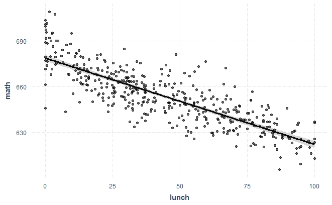

```r
library(ggplot2)
library(jtools)
effect_plot(reg1, pred=lunch, interval = TRUE, plot.points=TRUE)
```

```r
NA
NA
```

And our second regression

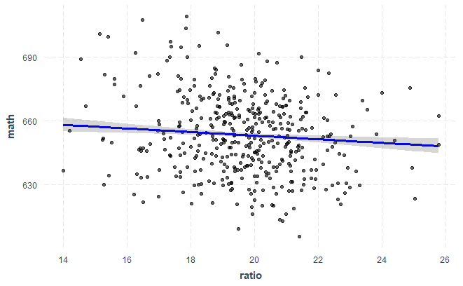

```r
effect_plot(reg2, pred=ratio, interval = TRUE, plot.points=TRUE, colors="blue")
```

## Links to useful stuff

[Richard Blissett & Benjamin Skinner - R and STATA side-by-side: Basic commands and processes](http://rslblissett.com/wp-content/uploads/2016/09/sidebyside_130826.pdf)

[Matthieu Gomez - R for STATA users](https://www.matthieugomez.com/statar/)

[RStudio - Cheat sheets](https://rstudio.com/resources/cheatsheets/#contributed-cheatsheets)

[Roger Peng - Intro to the `dplyr` R package](https://www.youtube.com/watch?v=aywFompr1F4)

[William Sundstrom & Michael Kevane - Guide to R: Data analysis for economics (includes code and data)](https://www.dropbox.com/sh/9pz2xtvd31mi4cl/AAAzG8g0D1YVByu7Mrxztxrga?dl=0)